# Brexit elasticities core results documentation

# Prepare the dataset

This chunk loads the main data set and prepares the analysis sample. First, the Excel file containing the full applicant data set is imported (it is also pre-filtered). Non-comparable territories and aggregate categories are removed to ensure that only consistent country units remain. Two country groups are then defined: EU member states (`eu_real`), which represent the treated group, and a synthetic comparison set (`eu_synth`) used as the control pool. The data set is restricted to observations belonging to these two groups and to years after 2015.

```r
library(readxl)
library(dplyr)

# we will pull the data only once and then reference it if necessary

data_full <- read_excel(
  "data_filtered.xlsx",
  sheet = "full_data"
)

eu_real <- c(
  "Austria", "Belgium", "Bulgaria", "Croatia", "Cyprus (European Union)",
  "Czech Republic", "Denmark", "Estonia", "Finland", "France",
  "Germany", "Greece", "Hungary",  "Italy",
  "Latvia", "Lithuania", "Luxembourg", "Malta", "Netherlands",
  "Poland", "Portugal", "Romania", "Slovakia", "Slovenia",
  "Spain", "Sweden"
)
```

```r
# Pull the synthetic EU from the directory (all the identified donor names)
eu_synth <- read_excel("~/GitHub/Estimating_price_elasticity/Statistical_documentation_in_R/Control_group_construction/control_group_output.xlsx", sheet = "weights")$donor_country

# now pull out the weights that were computed

weights<-read_excel("~/GitHub/Estimating_price_elasticity/Statistical_documentation_in_R/Control_group_construction/control_group_output.xlsx", sheet = "weights")

weights<-weights[,c("donor_country","regression_weight" )]

names(weights)[1]<-"Domicile_named_country"

#Prepare a new database with the same structure as weights so you can merge it with the main df

eu_to_merge<-as.data.frame(eu_real) %>% mutate(regression_weight=1)

names(eu_to_merge)[1]<-"Domicile_named_country"

#The new database was computed, the new weights and the old weights were stacked onto each other

weights<-bind_rows(eu_to_merge, weights)
```

Now create a filtered copy of the database to use in the regressions

```r
#Copy
data_UCAS  <- data_full %>%
  filter(Domicile_named_country %in% c(eu_real, eu_synth))

# Create relevant indicators

data_UCAS <- data_UCAS %>%
  mutate(
    real_EU  = ifelse(Domicile_named_country %in% eu_real, 1, 0),
    synth_EU = ifelse(Domicile_named_country %in% eu_synth, 1, 0),
    EU_group = case_when(
      Domicile_named_country %in% eu_real ~ "Real_EU",
      Domicile_named_country %in% eu_synth ~ "Synthetic_EU",
      TRUE ~ "Other"
    )
  )

# add the weights

data_UCAS<-merge(data_UCAS, weights, by="Domicile_named_country")
print(unique(data_UCAS$Domicile_named_country))
```

```
 [1] "Australia"                    "Austria"
 [3] "Belgium"                      "Botswana"
 [5] "Brunei Darussalam"            "Bulgaria"
 [7] "China"                        "Croatia"
 [9] "Cyprus (European Union)"      "Czech Republic"
[11] "Denmark"                      "Egypt"
[13] "Estonia"                      "Finland"
[15] "France"                       "Germany"
[17] "Greece"                       "Hungary"
[19] "Indonesia"                    "Iran, Islamic Republic of"
[21] "Ireland"                      "Israel"
[23] "Italy"                        "Korea, Republic of"
[25] "Latvia"                       "Lebanon"
[27] "Lithuania"                    "Luxembourg"
[29] "Malaysia"                     "Malta"
[31] "Mauritius"                    "Mexico"
[33] "Netherlands"                  "New Zealand"
[35] "Norway"                       "Poland"
[37] "Portugal"                     "Qatar"
[39] "Romania"                      "Russian Federation"
[41] "Slovakia"                     "Slovenia"
[43] "Spain"                        "Sweden"
[45] "Switzerland"                  "Tanzania, United Republic of"
[47] "Trinidad and Tobago"          "Turkey"
[49] "Uganda"                       "United Arab Emirates"
[51] "United States of America"     "Zimbabwe"
```

```r
table(data_UCAS$EU_group)
```

```
     Real_EU Synthetic_EU
         260          260
```

```r
head(data_UCAS)
```

|  | Domicile_named_country | Year | Applicants | Accepted_applicants | Acceptance_rate | Applicants_with_no_applications | real_EU | synth_EU | EU_group | regression_weight |
| --- | --- | --- | --- | --- | --- | --- | --- | --- | --- | --- |
| 1 | Australia | 2016 | 580 | 190 | 0.33 | 0 | 0 | 1 | Synthetic_EU | 0.4358215 |
| 2 | Australia | 2017 | 600 | 205 | 0.341 | 0 | 0 | 1 | Synthetic_EU | 0.4358215 |
| 3 | Australia | 2018 | 610 | 190 | 0.307 | 0 | 0 | 1 | Synthetic_EU | 0.4358215 |
| 4 | Australia | 2019 | 635 | 240 | 0.374 | 5 | 0 | 1 | Synthetic_EU | 0.4358215 |
| 5 | Australia | 2020 | 595 | 230 | 0.388 | 5 | 0 | 1 | Synthetic_EU | 0.4358215 |
| 6 | Australia | 2021 | 755 | 380 | 0.505 | 5 | 0 | 1 | Synthetic_EU | 0.4358215 |

Next we perform a sanity check:

```r
data_UCAS <- data_UCAS %>%
  mutate(
    EU_group = case_when(
      Domicile_named_country %in% eu_real  ~ "Real_EU",
      Domicile_named_country %in% eu_synth ~ "Synthetic_EU"
    )
  )
table(data_UCAS$EU_group)
```

```
     Real_EU Synthetic_EU
         260          260
```

260/10 = 26 real European countries (excl. Ireland because it didn’t face the same restrictions (-1) and excluding UK for obvious reasons (-1)) and 260/10=26 synthetic countries (including Ireland because it is the most plausible counter-factual)

# Saturated DID

## S-DID design with DK errors

This chunk estimates a pooled difference-in-differences model using `fixest::feols` with Driscoll–Kraay (DK) standard errors. We convert the panel object to a plain data frame, ensure `Year` and country identifiers have the correct types, and define the post-treatment period (`Post = 1` for years ≥ 2021) and treatment status (`Treated = 1` for countries in `eu_real`). To allow heterogeneous post effects for each treated country while pooling all non-treated units, we build `treated_factor`: treated countries keep their own country label, while all controls are set to `"CONTROL"` (used as the reference category).

The interaction term `i(treated_factor, Post, ref = "CONTROL")` estimates a separate post-treatment effect for each treated country relative to the pooled control group. Formally, the specification can be written as

$$\log(Applicants_{it}) =
\alpha_i + \lambda_t +
\sum_{c \in \mathcal{T}} \beta_c
\left( \mathbf{1}\{i = c\} \times Post_t \right)
+ \varepsilon_{it},$$

where $i$ indexes countries and $t$ indexes years, $\alpha_i$ and $\lambda_t$ denote country and year fixed effects, $\mathcal{T}$ is the set of treated (EU) countries, and $Post_t$ equals 1 for $t \geq 2021$.  
Each coefficient $\beta_c$ captures the post-Brexit change in applications for treated country $c$ relative to the pooled control group.

### Data prep

```r
library(fixest)

# make a copy of the original UCAS database to use in the following regressions
df <- data_UCAS
df$Domicile_named_country <- as.character(df$Domicile_named_country)
df$Year <- as.integer(as.character(df$Year))

# treatment definition
df$Post    <- as.integer(df$Year >= 2021)                 # post-Brexit
df$Treated <- as.integer(df$Domicile_named_country %in% eu_real)

# pooled control category (NO NA on RHS!)
df$treated_factor <- ifelse(
  df$Treated == 1,
  df$Domicile_named_country,   # each treated country gets its own coefficient
  "CONTROL"                     # all unaffected countries pooled
)
```

### Models

```r
m_sat_DK <- feols(
  log(Applicants) ~ i(treated_factor, Post, ref = "CONTROL") |
    Domicile_named_country + Year,
  data = df,
  panel.id = ~ Domicile_named_country + Year,
  vcov = "DK",
  weights = ~regression_weight
)

m_sat_DK1 <- feols(
  log(Applicants) ~ i(treated_factor, Post, ref = "CONTROL") |
    Domicile_named_country,
  data = df,
  panel.id = ~ Domicile_named_country + Year,
  vcov = "DK",
  weights = ~regression_weight
)

m_sat_DK2 <- feols(
  log(Applicants) ~ i(treated_factor, Post, ref = "CONTROL"),
  data = df,
  panel.id = ~ Domicile_named_country + Year,
  vcov = "DK",
  weights = ~regression_weight
)

m_sat_DK3 <- feols(
  log(Applicants) ~ i(treated_factor, Post, ref = "CONTROL")|Domicile_named_country + Year,
  data = df,
  panel.id = ~ Domicile_named_country + Year,
  vcov = "DK"
)
```

```r
summary(m_sat_DK)
```

```
OLS estimation, Dep. Var.: log(Applicants)
Observations: 520
Weights: regression_weight
Fixed-effects: Domicile_named_country: 52,  Year: 10
Standard-errors: Driscoll-Kraay (L=1)
```

|  | Estimate | Std. Error | t value | Pr(>\|t\|) |  |
| --- | --- | --- | --- | --- | --- |
| treated_factor::Austria:Post | -0.548534 | 0.053467 | -10.25928 | 2.8904e-06 | *** |
| treated_factor::Belgium:Post | -0.602657 | 0.066890 | -9.00962 | 8.4638e-06 | *** |
| treated_factor::Bulgaria:Post | -1.887146 | 0.132273 | -14.26710 | 1.7416e-07 | *** |
| treated_factor::Croatia:Post | -1.654745 | 0.109941 | -15.05119 | 1.0952e-07 | *** |
| treated_factor::Cyprus (European Union):Post | -0.902163 | 0.068076 | -13.25238 | 3.2916e-07 | *** |
| treated_factor::Czech Republic:Post | -1.137201 | 0.056221 | -20.22720 | 8.2184e-09 | *** |
| treated_factor::Denmark:Post | -1.046503 | 0.110554 | -9.46603 | 5.6390e-06 | *** |
| treated_factor::Estonia:Post | -1.447445 | 0.118991 | -12.16433 | 6.8570e-07 | *** |
| treated_factor::Finland:Post | -1.756347 | 0.208045 | -8.44213 | 1.4366e-05 | *** |
| treated_factor::France:Post | -0.597106 | 0.062240 | -9.59360 | 5.0486e-06 | *** |

[output cut: 16 more lines]

```
---
Signif. codes:  0 '***' 0.001 '**' 0.01 '*' 0.05 '.' 0.1 ' ' 1
RMSE: 0.153437     Adj. R2: 0.98022
                 Within R2: 0.820738
```

```r
summary(m_sat_DK1)
```

```
OLS estimation, Dep. Var.: log(Applicants)
Observations: 520
Weights: regression_weight
Fixed-effects: Domicile_named_country: 52
Standard-errors: Driscoll-Kraay (L=1)
```

|  | Estimate | Std. Error | t value | Pr(>\|t\|) |  |
| --- | --- | --- | --- | --- | --- |
| treated_factor::Austria:Post | -0.525213 | 0.051336 | -10.23088 | 2.9581e-06 | *** |
| treated_factor::Belgium:Post | -0.579336 | 0.063442 | -9.13173 | 7.5800e-06 | *** |
| treated_factor::Bulgaria:Post | -1.863825 | 0.128181 | -14.54054 | 1.4776e-07 | *** |
| treated_factor::Croatia:Post | -1.631423 | 0.104907 | -15.55111 | 8.2430e-08 | *** |
| treated_factor::Cyprus (European Union):Post | -0.878841 | 0.065872 | -13.34175 | 3.1067e-07 | *** |
| treated_factor::Czech Republic:Post | -1.113880 | 0.051462 | -21.64482 | 4.5172e-09 | *** |
| treated_factor::Denmark:Post | -1.023182 | 0.104812 | -9.76208 | 4.3708e-06 | *** |
| treated_factor::Estonia:Post | -1.424123 | 0.114933 | -12.39094 | 5.8571e-07 | *** |
| treated_factor::Finland:Post | -1.733025 | 0.203662 | -8.50931 | 1.3474e-05 | *** |
| treated_factor::France:Post | -0.573784 | 0.058507 | -9.80705 | 4.2072e-06 | *** |

[output cut: 16 more lines]

```
---
Signif. codes:  0 '***' 0.001 '**' 0.01 '*' 0.05 '.' 0.1 ' ' 1
RMSE: 0.165243     Adj. R2: 0.977526
                 Within R2: 0.867156
```

```r
summary(m_sat_DK2)
```

```
OLS estimation, Dep. Var.: log(Applicants)
Observations: 520
Weights: regression_weight
Standard-errors: Driscoll-Kraay (L=1)
```

|  | Estimate | Std. Error | t value | Pr(>\|t\|) |  |
| --- | --- | --- | --- | --- | --- |
| (Intercept) | 6.844046 | 0.031906 | 214.505711 | < 2.2e-16 | *** |
| treated_factor::Austria:Post | -0.960755 | 0.046134 | -20.825241 | 6.3542e-09 | *** |
| treated_factor::Belgium:Post | -0.433812 | 0.059074 | -7.343499 | 4.3574e-05 | *** |
| treated_factor::Bulgaria:Post | -1.006326 | 0.100976 | -9.965996 | 3.6811e-06 | *** |
| treated_factor::Croatia:Post | -2.572077 | 0.097999 | -26.245846 | 8.1707e-10 | *** |
| treated_factor::Cyprus (European Union):Post | 0.255082 | 0.041971 | 6.077531 | 1.8420e-04 | *** |
| treated_factor::Czech Republic:Post | -0.900870 | 0.052004 | -17.322986 | 3.2118e-08 | *** |
| treated_factor::Denmark:Post | -1.609199 | 0.093212 | -17.263907 | 3.3094e-08 | *** |
| treated_factor::Estonia:Post | -2.237089 | 0.104046 | -21.500887 | 4.7918e-09 | *** |
| treated_factor::Finland:Post | -1.817033 | 0.174310 | -10.424147 | 2.5296e-06 | *** |

[output cut: 17 more lines]

```
---
Signif. codes:  0 '***' 0.001 '**' 0.01 '*' 0.05 '.' 0.1 ' ' 1
RMSE: 0.993409   Adj. R2: 0.271762
```

```r
summary(m_sat_DK3)
```

```
OLS estimation, Dep. Var.: log(Applicants)
Observations: 520
Fixed-effects: Domicile_named_country: 52,  Year: 10
Standard-errors: Driscoll-Kraay (L=1)
```

|  | Estimate | Std. Error | t value | Pr(>\|t\|) |  |
| --- | --- | --- | --- | --- | --- |
| treated_factor::Austria:Post | -0.686029 | 0.080635 | -8.50783 | 1.3493e-05 | *** |
| treated_factor::Belgium:Post | -0.740152 | 0.094412 | -7.83960 | 2.6013e-05 | *** |
| treated_factor::Bulgaria:Post | -2.024641 | 0.159779 | -12.67153 | 4.8359e-07 | *** |
| treated_factor::Croatia:Post | -1.792240 | 0.131220 | -13.65825 | 2.5385e-07 | *** |
| treated_factor::Cyprus (European Union):Post | -1.039658 | 0.097165 | -10.69994 | 2.0320e-06 | *** |
| treated_factor::Czech Republic:Post | -1.274697 | 0.065362 | -19.50218 | 1.1339e-08 | *** |
| treated_factor::Denmark:Post | -1.183999 | 0.133662 | -8.85814 | 9.7212e-06 | *** |
| treated_factor::Estonia:Post | -1.584940 | 0.145137 | -10.92028 | 1.7117e-06 | *** |
| treated_factor::Finland:Post | -1.893842 | 0.234771 | -8.06677 | 2.0711e-05 | *** |
| treated_factor::France:Post | -0.734601 | 0.086036 | -8.53826 | 1.3109e-05 | *** |

[output cut: 16 more lines]

```
---
Signif. codes:  0 '***' 0.001 '**' 0.01 '*' 0.05 '.' 0.1 ' ' 1
RMSE: 0.173376     Adj. R2: 0.976761
                 Within R2: 0.809857
```

## Event study

This chunk estimates an event-study difference-in-differences model using `fixest`. We define treatment status as $EU_i=1$ for countries in `eu_real` and construct event time as $\ell = t - 2020$, so $\ell=0$ corresponds to year 2020. The regression uses `i(event_time, EU, ref = 0)` to estimate a full set of dynamic EU–control differences for each relative year $\ell$, normalized to zero in the reference period $\ell=0$. Country and year fixed effects are included, standard errors are clustered, and `iplot()` visualizes the estimated dynamic coefficients with $\ell=0$ shown as the reference line.

$$\log(Applicants_{it})=\alpha_i+\lambda_t+\sum_{\ell\neq
0}\beta_{\ell}\Big(\mathbf{1}\{t-2020=\ell\}\times
EU_i\Big)+\varepsilon_{it},$$

where $\beta_{\ell}$ traces the dynamic EU–control difference in year $\ell$ relative to the baseline year $\ell=0$ (2020).

### Event graph

```r
library(fixest)

# to perform the following chunks transform Year to numeric

df$Year <- as.integer(as.character(df$Year))

# treatment definition

df$Post    <- as.integer(df$Year >= 2021)
df$EU      <- as.integer(df$Domicile_named_country %in% eu_real)

# event-time (ℓ = t − 2020)

df$event_time <- df$Year - 2020

# pooled EU vs control event-study DID

m_event <- feols(
  log(Applicants) ~ i(event_time, EU, ref = 0) |
    Domicile_named_country + Year,
  data = df,
  panel.id = ~ Domicile_named_country + Year,
  vcov="cluster",
  weights=~regression_weight
)

summary(m_event)
```

```
OLS estimation, Dep. Var.: log(Applicants)
Observations: 520
Weights: regression_weight
Fixed-effects: Domicile_named_country: 52,  Year: 10
Standard-errors: Clustered (Domicile_named_country)
```

|  | Estimate | Std. Error | t value | Pr(>\|t\|) |  |
| --- | --- | --- | --- | --- | --- |
| event_time::-4:EU | -0.011041 | 0.069679 | -0.158454 | 8.7472e-01 |  |
| event_time::-3:EU | 0.000296 | 0.053097 | 0.005571 | 9.9558e-01 |  |
| event_time::-2:EU | 0.002465 | 0.039844 | 0.061858 | 9.5092e-01 |  |
| event_time::-1:EU | 0.012990 | 0.026024 | 0.499135 | 6.1983e-01 |  |
| event_time::1:EU | -0.759902 | 0.091818 | -8.276221 | 5.3890e-11 | *** |
| event_time::2:EU | -1.103977 | 0.116830 | -9.449422 | 8.5764e-13 | *** |
| event_time::3:EU | -1.209472 | 0.128029 | -9.446885 | 8.6523e-13 | *** |
| event_time::4:EU | -1.222644 | 0.125288 | -9.758690 | 2.9466e-13 | *** |
| event_time::5:EU | -1.243544 | 0.125723 | -9.891152 | 1.8708e-13 | *** |

```
---
Signif. codes:  0 '***' 0.001 '**' 0.01 '*' 0.05 '.' 0.1 ' ' 1
RMSE: 0.224506     Adj. R2: 0.959252
                 Within R2: 0.616217
```

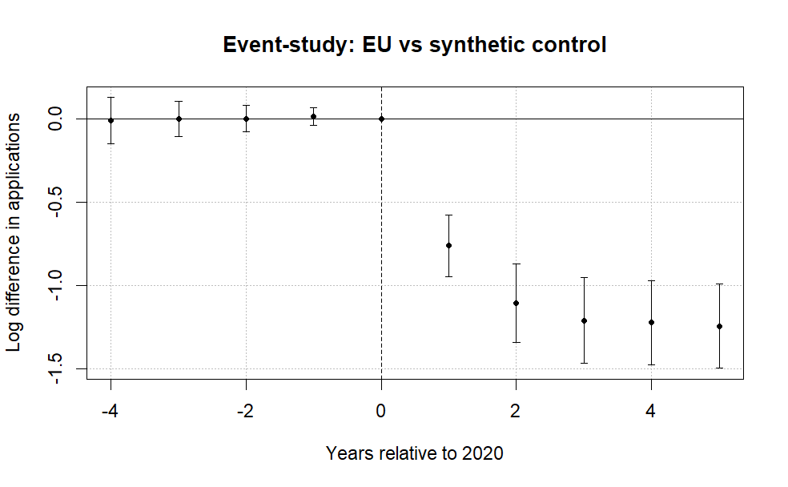

```r
iplot(
  m_event,
  xlab = "Years relative to 2020",
  ylab = "Log difference in applications",
  ref.line = 0,
  main = "Event-study: EU vs synthetic control"
)
```

```r
# Quick Wald test to insure robustness
wald(m_event, c(
"event_time::-4:EU",
"event_time::-3:EU",
"event_time::-2:EU",
"event_time::-1:EU"
))
```

```
Wald test, H0: joint nullity of event_time::-4:EU, event_time::-3:EU, event_time::-2:EU and event_time::-1:EU
 stat = 0.159282, p-value = 0.958738, on 4 and 450 DoF, VCOV: Clustered (Domicile_named_country).
```

Interestingly, if we remove the clustering the following happens:

```r
etable(m_event, vcov="iid")
```

```
                                   m_event
Dependent Var.:            log(Applicants)

EU x event_time = -4      -0.0110 (0.0947)
EU x event_time = -3       0.0003 (0.0947)
EU x event_time = -2       0.0025 (0.0947)
EU x event_time = -1       0.0130 (0.0947)
EU x event_time = 1    -0.7599*** (0.0947)
EU x event_time = 2     -1.104*** (0.0947)
EU x event_time = 3     -1.209*** (0.0947)
EU x event_time = 4     -1.223*** (0.0947)
EU x event_time = 5     -1.244*** (0.0947)
Fixed-Effects:         -------------------
Domicile_named_country                 Yes
Year                                   Yes
______________________ ___________________
S.E. type                              IID
Observations                           520
R2                                 0.96467
Within R2                          0.61622
---
Signif. codes: 0 '***' 0.001 '**' 0.01 '*' 0.05 '.' 0.1 ' ' 1
```

notice that the standard errors are equal everywhere. Under iid (homoskedastic) errors, the event-time dummies will have the same variance in this design, and therefore identical standard errors. That follows directly from the mechanics of OLS. With iid errors, the variance of each coefficient depends only on

$$Var(\hat{\delta}_l)=\sigma^2(X_l'X_l'^{-1})$$

and the second moment of the regressor, and since each event-time dummy has identical support and variance after fixed effects, their estimated variances must be the same.

### Placebo graph

This chunk implements a placebo event-study to test for spurious pre-treatment dynamics. A fake treatment year is set to 2018 and event time is defined as $\ell = t - 2018$. The specification `i(event_time_pl2018, EU, ref = -1)` estimates EU–control differences for each relative year while normalizing the year immediately before the placebo treatment ($\ell=-1$) to zero. Country and year fixed effects are included, and standard errors are clustered at the country level. The resulting coefficients are plotted to visually assess whether significant effects appear around the placebo treatment date.

$$\log(Applicants_{it}) =
\alpha_i + \lambda_t +
\sum_{\ell \neq -1} \beta_{\ell}
\left(\mathbf{1}\{t-2018=\ell\} \times EU_i\right)
+ \varepsilon_{it},$$

where the coefficients $\beta_{\ell}$ capture placebo EU–control differences relative to the pre-placebo year $\ell=-1$.

```r
#placebo event time (fake Brexit in 2018)

df$event_time_pl2018 <- df$Year - 2018

m_placebo_2018 <- feols(
  log(Applicants) ~ i(event_time_pl2018, EU, ref = -1) |
  Domicile_named_country + Year,
  data = df,
  panel.id = ~ Domicile_named_country + Year,
  cluster=~Domicile_named_country,
  weights =~ regression_weight
)

summary(m_placebo_2018)
```

```
OLS estimation, Dep. Var.: log(Applicants)
Observations: 520
Weights: regression_weight
Fixed-effects: Domicile_named_country: 52,  Year: 10
Standard-errors: Clustered (Domicile_named_country)
```

|  | Estimate | Std. Error | t value | Pr(>\|t\|) |  |
| --- | --- | --- | --- | --- | --- |
| event_time_pl2018::-2:EU | -0.011337 | 0.029580 | -0.383253 | 7.0313e-01 |  |
| event_time_pl2018::0:EU | 0.002169 | 0.035629 | 0.060873 | 9.5170e-01 |  |
| event_time_pl2018::1:EU | 0.012694 | 0.042395 | 0.299419 | 7.6584e-01 |  |
| event_time_pl2018::2:EU | -0.000296 | 0.053097 | -0.005571 | 9.9558e-01 |  |
| event_time_pl2018::3:EU | -0.760198 | 0.109772 | -6.925253 | 7.1434e-09 | *** |
| event_time_pl2018::4:EU | -1.104272 | 0.124212 | -8.890236 | 6.0729e-12 | *** |
| event_time_pl2018::5:EU | -1.209768 | 0.139722 | -8.658371 | 1.3796e-11 | *** |
| event_time_pl2018::6:EU | -1.222940 | 0.136454 | -8.962279 | 4.7110e-12 | *** |
| event_time_pl2018::7:EU | -1.243840 | 0.140603 | -8.846456 | 7.0879e-12 | *** |

```
---
Signif. codes:  0 '***' 0.001 '**' 0.01 '*' 0.05 '.' 0.1 ' ' 1
RMSE: 0.224506     Adj. R2: 0.959252
                 Within R2: 0.616217
```

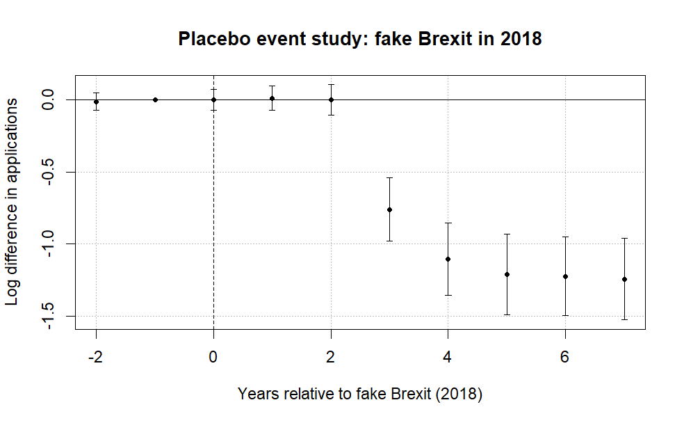

```r
# plot
iplot(
  m_placebo_2018,
  xlab = "Years relative to fake Brexit (2018)",
  ylab = "Log difference in applications",
  ref.line = 0,
  main = "Placebo event study: fake Brexit in 2018"
)
```

```r
# leads-only sample (pre-2021 only)

df_pre <- subset(df, Year < 2021)

df_pre$event_time <- df_pre$Year - 2020

m_leads_only <- feols(
  log(Applicants) ~ i(event_time, EU, ref = 0) |
    Domicile_named_country + Year,
  data = df_pre,
  panel.id = ~ Domicile_named_country + Year,
  cluster = ~Domicile_named_country,
  weights = ~regression_weight
)

summary(m_leads_only)
```

```
OLS estimation, Dep. Var.: log(Applicants)
Observations: 260
Weights: regression_weight
Fixed-effects: Domicile_named_country: 52,  Year: 5
Standard-errors: Clustered (Domicile_named_country)
```

|  | Estimate | Std. Error | t value | Pr(>\|t\|) |  |
| --- | --- | --- | --- | --- | --- |
| event_time::-4:EU | -0.011041 | 0.069542 | -0.158765 | 0.87448 |  |
| event_time::-3:EU | 0.000296 | 0.052993 | 0.005582 | 0.99557 |  |
| event_time::-2:EU | 0.002465 | 0.039766 | 0.061979 | 0.95082 |  |
| event_time::-1:EU | 0.012990 | 0.025973 | 0.500115 | 0.61915 |  |

```
---
Signif. codes:  0 '***' 0.001 '**' 0.01 '*' 0.05 '.' 0.1 ' ' 1
RMSE: 0.088292     Adj. R2: 0.991606
                 Within R2: 0.001872
```

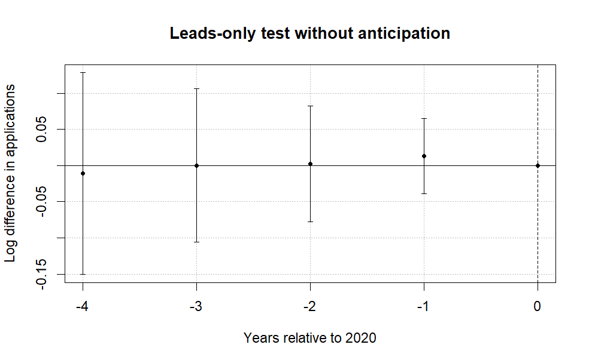

```r
iplot(
  m_leads_only,
  xlab = "Years relative to 2020",
  ylab = "Log difference in applications",
  ref.line = 0,
  main = "Leads-only test without anticipation"
)
```

```r
wald(m_leads_only, c(
"event_time::-4:EU",
"event_time::-3:EU",
"event_time::-2:EU",
"event_time::-1:EU"
))
```

```
Wald test, H0: joint nullity of event_time::-4:EU, event_time::-3:EU, event_time::-2:EU and event_time::-1:EU
 stat = 0.159908, p-value = 0.958308, on 4 and 200 DoF, VCOV: Clustered (Domicile_named_country).
```

## Saturated event study

```r
library(fixest)

#make a copy of the base dataset for UCAS
df <- data_UCAS

# make sure these are plain base variables

df$Domicile_named_country <- as.character(df$Domicile_named_country)
df$Year <- as.integer(as.character(df$Year))

df$event_time <- df$Year - 2020

# Now create a dummy category for each

df$Treated <- df$Domicile_named_country %in% eu_real

df$treated_factor <- ifelse(
  df$Treated,
  df$Domicile_named_country,
  "CONTROL"
)

df$treated_factor <- factor(df$treated_factor)

# sanity checks

levels(df$treated_factor)
```

```
 [1] "Austria"                 "Belgium"                 "Bulgaria"
 [4] "CONTROL"                 "Croatia"                 "Cyprus (European Union)"
 [7] "Czech Republic"          "Denmark"                 "Estonia"
[10] "Finland"                 "France"                  "Germany"
[13] "Greece"                  "Hungary"                 "Italy"
[16] "Latvia"                  "Lithuania"               "Luxembourg"
[19] "Malta"                   "Netherlands"             "Poland"
[22] "Portugal"                "Romania"                 "Slovakia"
[25] "Slovenia"                "Spain"                   "Sweden"
```

```r
length(levels(df$treated_factor))
```

```
[1] 27
```

```r
m_sat_event <- feols(
  log(Applicants) ~ i(event_time, treated_factor, ref = 0, ref2 = "CONTROL") |
    Domicile_named_country + Year,
  data = df,
  panel.id = ~Domicile_named_country + Year,
   vcov = "DK",
  weights = ~regression_weight
)
summary(m_sat_event)
```

```
OLS estimation, Dep. Var.: log(Applicants)
Observations: 520
Weights: regression_weight
Fixed-effects: Domicile_named_country: 52,  Year: 10
Standard-errors: Driscoll-Kraay (L=1)
```

|  | Estimate | Std. Error | t value | Pr(>\|t\|) |  |
| --- | --- | --- | --- | --- | --- |
| event_time::-4:treated_factor::Austria | 0.133496 | 1e-06 | 133495.96 | < 2.2e-16 | *** |
| event_time::-4:treated_factor::Belgium | 0.068382 | 1e-06 | 68381.91 | < 2.2e-16 | *** |
| event_time::-4:treated_factor::Bulgaria | 0.228607 | 1e-06 | 228607.35 | < 2.2e-16 | *** |
| event_time::-4:treated_factor::Croatia | 0.021250 | 1e-06 | 21250.11 | < 2.2e-16 | *** |
| event_time::-4:treated_factor::Cyprus (European Union) | 0.134220 | 1e-06 | 134220.02 | < 2.2e-16 | *** |
| event_time::-4:treated_factor::Czech Republic | -0.202335 | 1e-06 | -202335.46 | < 2.2e-16 | *** |
| event_time::-4:treated_factor::Denmark | 0.067538 | 1e-06 | 67537.99 | < 2.2e-16 | *** |
| event_time::-4:treated_factor::Estonia | 0.127710 | 1e-06 | 127710.02 | < 2.2e-16 | *** |
| event_time::-4:treated_factor::Finland | 0.291103 | 1e-06 | 291102.95 | < 2.2e-16 | *** |
| event_time::-4:treated_factor::France | -0.010334 | 1e-06 | -10333.68 | < 2.2e-16 | *** |

[output cut: 224 more lines]

```
---
Signif. codes:  0 '***' 0.001 '**' 0.01 '*' 0.05 '.' 0.1 ' ' 1
RMSE: 0.110155     Adj. R2: 0.98038
                 Within R2: 0.907607
```

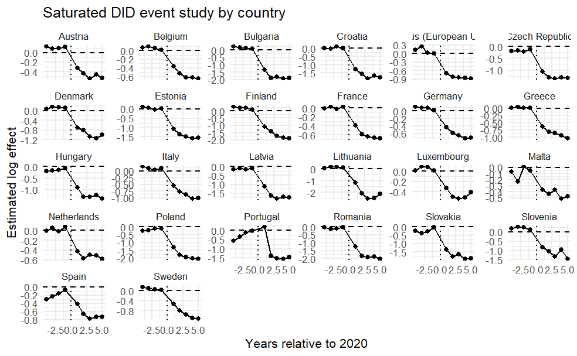

```r
library(broom)
library(dplyr)
library(stringr)
library(ggplot2)

plot_df <- broom::tidy(m_sat_event) %>%
  filter(str_detect(term, "^event_time::")) %>%
  mutate(
    event_time = as.integer(str_extract(term, "-?\\d+(?=:)")),
    country = str_extract(term, "(?<=treated_factor::).*"),
    conf.low = estimate - 1.96 * std.error,
    conf.high = estimate + 1.96 * std.error
  ) %>%
  filter(!is.na(country), country != "CONTROL")

ggplot(plot_df, aes(x = event_time, y = estimate)) +
  geom_hline(yintercept = 0, linetype = "dashed") +
  geom_vline(xintercept = 0, linetype = "dotted") +
  geom_point(size = 1.6) +
  geom_line() +
  geom_errorbar(
    aes(ymin = conf.low, ymax = conf.high),
    width = 0.15
  ) +
  facet_wrap(~ country, scales = "free_y") +
  theme_minimal() +
  labs(
    x = "Years relative to 2020",
    y = "Estimated log effect",
    title = "Saturated DID event study by country"
  )
```

## D-El from S-DID compared with mechanical and fee based

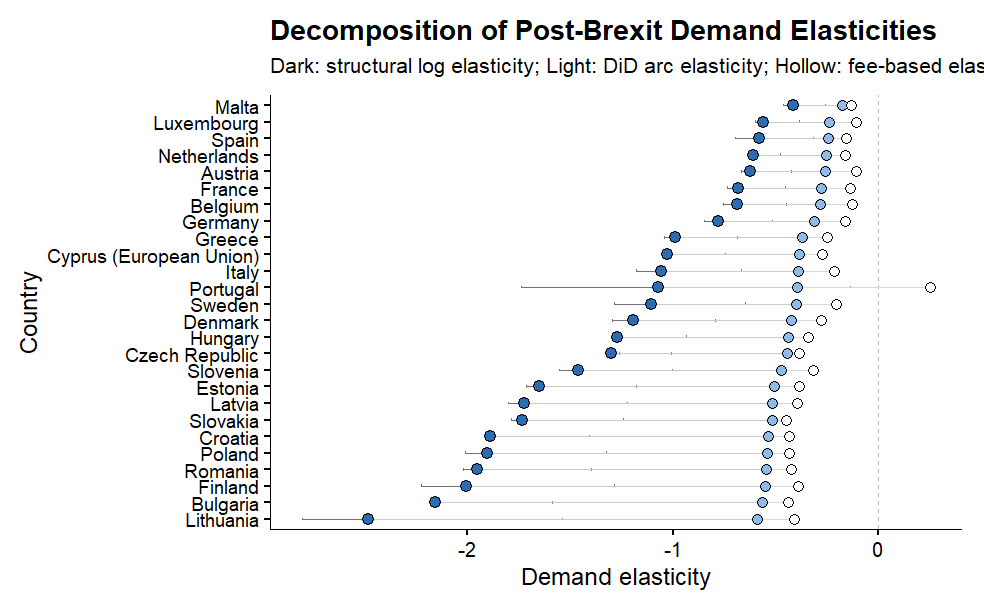

```r
library(dplyr)
library(ggplot2)
library(broom)

# 1. Brexit tuition shock

fee_pre  <- 9250
fee_post <- 22200

x <- log(fee_post)-log(fee_pre)                     # log price change
pct_fee_change <- (fee_post - fee_pre) / fee_pre   # ≈ 1.40

# 2. Elasticities from DiD regression

did_df <- tidy(m_sat_DK, conf.int = TRUE) %>%
  filter(grepl("^treated_factor::", term)) %>%
  mutate(
    country = gsub("^treated_factor::", "", term),
    country = gsub(":Post$", "", country),

    beta = estimate,   # Δ log Q (DiD semi-elasticity)

    # 1) DiD quantity change (log change)
    log_change = beta,
    conf_low_log  = conf.low,
    conf_high_log = conf.high,

    # 2) Arc elasticity from DiD
    eta_arc_did = (exp(beta) - 1) / pct_fee_change,

    # 3) Structural log elasticity
    eta_log = beta / x
  ) %>%
  select(country, log_change, conf_low_log, conf_high_log, eta_arc_did, eta_log)


# 3. Mechanical fee-based elasticity

fee_df <- df %>%
  filter(Domicile_named_country %in% eu_real) %>%
  group_by(Domicile_named_country) %>%
  summarise(
    app_pre  = mean(Applicants[Year == 2020], na.rm = TRUE),
    app_post = mean(Applicants[Year == 2021], na.rm = TRUE),

    # η_mechanical = %ΔQ / %ΔP
    eta_mechanical = ((app_post - app_pre) / app_pre) / pct_fee_change,
    .groups = "drop"
  ) %>%
  rename(country = Domicile_named_country)

# 4. Merge data sets

plot_df <- did_df %>%
  left_join(fee_df, by = "country") %>%
  arrange(eta_log) %>%
  mutate(
    country = factor(country, levels = country),

    # small horizontal offsets so points don’t overlap
    eta_arc_shift  = eta_arc_did + 0.04,
    eta_mech_shift = eta_mechanical + 0.08
  )

# 5. Plot

ggplot(plot_df, aes(y = country)) +

  # zero line
  geom_vline(
    xintercept = 0,
    linetype = "dashed",
    color = "grey70",
    linewidth = 0.35
  ) +

  # confidence intervals (only structural elasticity has SEs)
  geom_errorbarh(
    aes(xmin = conf_low_log, xmax = conf_high_log),
    height = 0.16,
    linewidth = 0.4,
    color = "grey45"
  ) +

  # connectors between estimates
  geom_segment(
    aes(x = eta_log, xend = eta_arc_shift, yend = country),
    color = "grey80",
    linewidth = 0.3
  ) +
  geom_segment(
    aes(x = eta_arc_shift, xend = eta_mech_shift, yend = country),
    color = "grey85",
    linewidth = 0.3
  ) +

  # (A) Structural elasticity (log derivative)
  geom_point(
    aes(x = eta_log),
    shape = 21,
    size = 2.8,
    fill = "#2C6DB2",
    color = "black",
    stroke = 0.25
  ) +

  # (B) DiD arc elasticity
  geom_point(
    aes(x = eta_arc_shift),
    shape = 21,
    size = 2.6,
    fill = "#8FBCE6",
    color = "black",
    stroke = 0.25
  ) +

  # (C) Mechanical fee elasticity
  geom_point(
    aes(x = eta_mech_shift),
    shape = 21,
    size = 2.6,
    fill = "white",
    color = "black",
    stroke = 0.25
  ) +

  labs(
    title = "Decomposition of Post-Brexit Demand Elasticities",
    subtitle = "Dark: structural log elasticity; Light: DiD arc elasticity; Hollow: fee-based elasticity",
    x = "Demand elasticity",
    y = "Country"
  ) +

  theme_classic(base_size = 13) +
  theme(
    plot.title = element_text(face="bold", size=15, margin=margin(b=6)),
    plot.subtitle = element_text(size=11, margin=margin(b=10)),
    axis.text.y = element_text(size=10),
    axis.line = element_line(linewidth=0.35),
    plot.margin = margin(10,12,10,10)
  )
```

```r
NA
NA
```

## S-DID design DE with COVID and Post-COVID coefficients

```r
df$Post_COVID <- as.integer(df$Year >= 2024)
df$Post <- as.integer(df$Year %in% c(2021,2022,2023) )

#pooled control category (NO NA on RHS!)

df$treated_factor <- ifelse(
  df$Treated == 1,
  df$Domicile_named_country,   # each treated country gets its own coefficient
  "CONTROL"                     # all unaffected countries pooled
)

library(fixest)

m_sat_DK_2 <- feols(
  log(Applicants) ~
    i(treated_factor, Post, ref = "CONTROL") +
    i(treated_factor, Post_COVID, ref = "CONTROL") |
    Domicile_named_country + Year,
  data = df,
  panel.id = ~ Domicile_named_country + Year,
  vcov = "DK",
  weights = ~regression_weight
)

summary(m_sat_DK_2)
```

```
OLS estimation, Dep. Var.: log(Applicants)
Observations: 520
Weights: regression_weight
Fixed-effects: Domicile_named_country: 52,  Year: 10
Standard-errors: Driscoll-Kraay (L=1)
```

|  | Estimate | Std. Error | t value | Pr(>\|t\|) |  |
| --- | --- | --- | --- | --- | --- |
| treated_factor::Austria:Post | -0.524079 | 0.072806 | -7.19830 | 5.0925e-05 | *** |
| treated_factor::Belgium:Post | -0.550717 | 0.078582 | -7.00814 | 6.2682e-05 | *** |
| treated_factor::Bulgaria:Post | -1.795417 | 0.170656 | -10.52065 | 2.3416e-06 | *** |
| treated_factor::Croatia:Post | -1.590876 | 0.159317 | -9.98558 | 3.6215e-06 | *** |
| treated_factor::Cyprus (European Union):Post | -0.869202 | 0.072421 | -12.00212 | 7.6883e-07 | *** |
| treated_factor::Czech Republic:Post | -1.106535 | 0.078670 | -14.06553 | 1.9697e-07 | *** |
| treated_factor::Denmark:Post | -0.962507 | 0.115662 | -8.32173 | 1.6132e-05 | *** |
| treated_factor::Estonia:Post | -1.341072 | 0.129471 | -10.35809 | 2.6678e-06 | *** |
| treated_factor::Finland:Post | -1.570826 | 0.207869 | -7.55680 | 3.4797e-05 | *** |
| treated_factor::France:Post | -0.542371 | 0.074106 | -7.31887 | 4.4734e-05 | *** |

[output cut: 42 more lines]

```
---
Signif. codes:  0 '***' 0.001 '**' 0.01 '*' 0.05 '.' 0.1 ' ' 1
RMSE: 0.145454     Adj. R2: 0.981089
                 Within R2: 0.838905
```

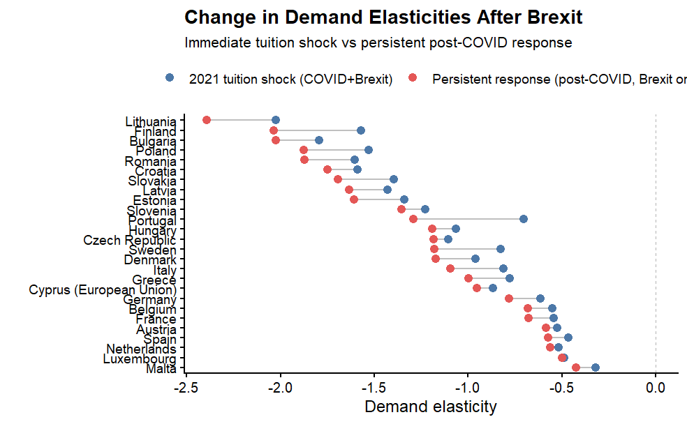

```r
library(dplyr)
library(ggplot2)
library(tidyr)
library(broom)
library(stringr)

# 1) extract coefficients
coef_long <- tidy(m_sat_DK_2) %>%
  filter(str_detect(term, "^treated_factor::")) %>%
  mutate(
    period = case_when(
      str_detect(term, "Post_COVID$") ~ "Post-COVID",
      str_detect(term, "Post$") ~ "Post-Brexit",
      TRUE ~ NA_character_
    ),
    country = term %>%
      str_remove("^treated_factor::") %>%
      str_remove(":(Post|Post_COVID)$"),
    elasticity = estimate
  ) %>%
  filter(!is.na(period))

# 2) wide version (for ordering + segments)
plot_df2 <- coef_long %>%
  select(country, period, elasticity) %>%
  pivot_wider(names_from = period, values_from = elasticity) %>%
  arrange(desc(`Post-COVID`)) %>%
  mutate(country = factor(country, levels = unique(country)))

# 3) long version (for legend + points)
plot_df_long <- plot_df2 %>%
  pivot_longer(
    cols = c(`Post-Brexit`, `Post-COVID`),
    names_to = "period",
    values_to = "elasticity"
  ) %>%
  mutate(
    period = factor(
      period,
      levels = c("Post-Brexit", "Post-COVID"),
      labels = c(
        "2021 tuition shock (COVID+Brexit)",
        "Persistent response (post-COVID, Brexit only)"
      )
    )
  )

# 4) plot
ggplot(plot_df_long, aes(y = country)) +

  # connecting lines (use wide data)
  geom_segment(
    data = plot_df2,
    aes(
      x = `Post-Brexit`,
      xend = `Post-COVID`,
      yend = country
    ),
    color = "grey75",
    linewidth = 0.6
  ) +

  # points with proper legend
  geom_point(
    aes(x = elasticity, color = period),
    size = 2.6
  ) +

  geom_vline(
    xintercept = 0,
    linetype = "dashed",
    color = "grey70",
    linewidth = 0.35
  ) +

  scale_color_manual(
    values = c("#4C78A8", "#E45756"),
    name = NULL
  ) +

  labs(
    title = "Change in Demand Elasticities After Brexit",
    subtitle = "Immediate tuition shock vs persistent post-COVID response",
    x = "Demand elasticity",
    y = ""
  ) +

  theme_classic(base_size = 13) +
  theme(
    plot.title = element_text(face = "bold", size = 15),
    plot.subtitle = element_text(size = 11),
    axis.text.y = element_text(size = 10),
    legend.position = "top",
    legend.text = element_text(size = 10)
  )
```

# Robustness P.I

## Step 1. Prepare data

```r
# Load UCAS data

data_raw <- read_excel(
  "data_filtered.xlsx",
  sheet = "full_data"
)

data_clean <- data_raw %>%
  filter(Year > 2015) %>%
  mutate(
    EU = as.integer(Domicile_named_country %in% eu_real),
    Post = as.integer(Year >= 2021),
    log_applicants = log(Applicants)
  )
```

## Step 2. Donor pools definitions

```r
# ------------------------------------------------------------
# Donor pools
# ------------------------------------------------------------

synth_poor <- c(
  "Pakistan",
  "Nepal",
  "Bangladesh",
  "Ethiopia",
  "Uganda",
  "Tanzania, United Republic of",
  "Rwanda",
  "Mozambique",
  "Malawi",
  "Sierra Leone",
  "Ghana",
  "Nigeria",
  "Kenya",
  "Zimbabwe"
)

synth_rich <- c(
  "United States of America",
  "Canada",
  "Australia",
  "Norway",
  "Switzerland",
  "Singapore",
  "Qatar",
  "United Arab Emirates",
  "Kuwait",
  "Saudi Arabia",
  "Israel",
  "Japan",
  "Hong Kong"
)

oecd <- c(
  "Australia",
  "Canada",
  "Chile",
  "Colombia",
  "Iceland",
  "Israel",
  "Japan",
  "Korea, Republic of",
  "Mexico",
  "New Zealand",
  "Norway",
  "Switzerland",
  "Turkey",
  "United States of America"
)
```

## Step 3. Analysis datasets

```r
data_baseline <- data_clean %>%
  filter(Domicile_named_country %in% c(eu_real, eu_synth)) %>%
  mutate(control_group = "Baseline synthetic")

data_poor <- data_clean %>%
  filter(Domicile_named_country %in% c(eu_real, synth_poor)) %>%
  mutate(control_group = "Very poor controls")

data_rich <- data_clean %>%
  filter(Domicile_named_country %in% c(eu_real, synth_rich)) %>%
  mutate(control_group = "Very rich controls")

data_oecd <- data_clean %>%
  filter(Domicile_named_country %in% c(eu_real, oecd)) %>%
  mutate(control_group = "OECD controls")
```

### ~Basic checks

```r
check_data <- function(df) {
  data.frame(
    observations = nrow(df),
    countries = length(unique(df$Domicile_named_country)),
    eu_countries = length(unique(df$Domicile_named_country[df$EU == 1])),
    control_countries = length(unique(df$Domicile_named_country[df$EU == 0])),
    first_year = min(df$Year, na.rm = TRUE),
    last_year = max(df$Year, na.rm = TRUE)
  )
}

data_checks <- bind_rows(
  "Baseline synthetic" = check_data(data_baseline),
  "Very poor controls" = check_data(data_poor),
  "Very rich controls" = check_data(data_rich),
  "OECD controls" = check_data(data_oecd),
  .id = "sample"
)

data_checks
```

| sample | observations | countries | eu_countries | control_countries | first_year | last_year |
| --- | --- | --- | --- | --- | --- | --- |
| Baseline synthetic | 520 | 52 | 26 | 26 | 2016 | 2025 |
| Very poor controls | 400 | 40 | 26 | 14 | 2016 | 2025 |
| Very rich controls | 390 | 39 | 26 | 13 | 2016 | 2025 |
| OECD controls | 400 | 40 | 26 | 14 | 2016 | 2025 |

## Step 4. Construct donor-pool-specific weights

```r
make_distance_weights <- function(df) {

  # Pre-treatment average EU trajectory

  eu_pre <- df %>%
    filter(EU == 1, Year < 2021) %>%
    group_by(Year) %>%
    summarise(
      eu_mean_log_applicants = mean(log_applicants, na.rm = TRUE),
      .groups = "drop"
    )

  # Distance of each control country from the EU pre-treatment path

  control_distances <- df %>%
    filter(EU == 0, Year < 2021) %>%
    select(Domicile_named_country, Year, log_applicants) %>%
    left_join(eu_pre, by = "Year") %>%
    group_by(Domicile_named_country) %>%
    summarise(
      distance = sqrt(mean(
        (log_applicants - eu_mean_log_applicants)^2,
        na.rm = TRUE
      )),
      .groups = "drop"
    ) %>%
    mutate(
      donor_weight = 1 / (distance + 0.001),
      donor_weight = donor_weight / mean(donor_weight, na.rm = TRUE)
    )

  # Treated EU countries receive weight 1.
  # Control countries receive distance-based donor weights.

  df %>%
    left_join(control_distances, by = "Domicile_named_country") %>%
    mutate(
      robustness_weight = ifelse(EU == 1, 1, donor_weight),
      robustness_weight = ifelse(is.na(robustness_weight), 1, robustness_weight)
    )
}
```

Apply the weights to each donor-pool database by using the dedicated functions for that.

```r
data_baseline_w <- make_distance_weights(data_baseline)
data_poor_w     <- make_distance_weights(data_poor)
data_rich_w     <- make_distance_weights(data_rich)
data_oecd_w     <- make_distance_weights(data_oecd)
```

## Step 5. Weighted and unweighted DiD models

```r
# First we define the basic function. It will compute a weighted and unweighted version of each regression.

run_weighted_unweighted <- function(df) {

  m_weighted <- feols(
    log_applicants ~ EU:Post | Domicile_named_country + Year,
    data = df,
    weights = ~ robustness_weight,
    panel.id = ~ Domicile_named_country + Year,
    vcov = "DK"
  )

  m_unweighted <- feols(
    log_applicants ~ EU:Post | Domicile_named_country + Year,
    data = df,
    panel.id = ~ Domicile_named_country + Year,
    vcov = "DK"
  )

  list(
    weighted = m_weighted,
    unweighted = m_unweighted
  )
}
```

Using that function we run the models in the following block:

```r
models_baseline <- run_weighted_unweighted(data_baseline_w)
models_poor     <- run_weighted_unweighted(data_poor_w)
models_rich     <- run_weighted_unweighted(data_rich_w)
models_oecd     <- run_weighted_unweighted(data_oecd_w)
```

Next we perform an Ireland specific robustness check here:

```r
eu_no_ireland <- setdiff(eu_real, "Ireland") #practically speaking the eu_real vector does not contain Ireland but just in case we remove it.

data_ireland <- data_clean %>%
  filter(Domicile_named_country %in% c(eu_no_ireland, "Ireland")) %>%
  mutate(
    EU = as.integer(Domicile_named_country %in% eu_no_ireland),
    Post = as.integer(Year >= 2021),
    control_group = "IRELAND"
  )

m_ireland_only <- feols(
  log_applicants ~ EU:Post| Domicile_named_country + Year,
  data = data_ireland,
  panel.id = ~ Domicile_named_country + Year,
  vcov = "DK"
)
```

```r
# Robustness table

etable(
  models_baseline$weighted,
  models_baseline$unweighted,
  models_poor$weighted,
  models_poor$unweighted,
  models_rich$weighted,
  models_rich$unweighted,
  models_oecd$weighted,
  models_oecd$unweighted,
  m_ireland_only,
  dict = c("EU:Post" = "EU × Post"),
  headers = c(
    "Baseline weighted",
    "Baseline unweighted",
    "Poor weighted",
    "Poor unweighted",
    "Rich weighted",
    "Rich unweighted",
    "OECD weighted",
    "OECD unweighted",
    "Ireland only"
  ),
  fitstat = ~ n + ar2 + wr2,
  tex = FALSE
)
```

```
                       models_baseline$.. models_baseline$...1 models_poor$weig..
                        Baseline weighted  Baseline unweighted      Poor weighted
Dependent Var.:            log_applicants       log_applicants     log_applicants

EU × Post             -1.195*** (0.1122)   -1.246*** (0.1203) -1.653*** (0.1683)
Fixed-Effects:         ------------------   ------------------ ------------------
Domicile_named_country                Yes                  Yes                Yes
Year                                  Yes                  Yes                Yes
______________________ __________________   __________________ __________________
S.E. type              Drisco.-Kra. (L=1)   Drisco.-Kra. (L=1) Drisco.-Kra. (L=1)
Observations                          520                  520                400
Adj. R2                           0.93192              0.95541            0.94093
Within R2                         0.57127              0.61413            0.65779

                       models_poor$unwe.. models_rich$weig.. models_rich$unwe..
                          Poor unweighted      Rich weighted    Rich unweighted
Dependent Var.:            log_applicants     log_applicants     log_applicants

EU × Post             -1.672*** (0.2039) -1.350*** (0.1532) -1.325*** (0.1342)
Fixed-Effects:         ------------------ ------------------ ------------------
Domicile_named_country                Yes                Yes                Yes
Year                                  Yes                Yes                Yes
______________________ __________________ __________________ __________________
S.E. type              Drisco.-Kra. (L=1) Drisco.-Kra. (L=1) Drisco.-Kra. (L=1)
Observations                          400                390                390
Adj. R2                           0.94356            0.92835            0.94572
Within R2                         0.62844            0.56883            0.58733

                       models_oecd$weig.. models_oecd$unwe..     m_ireland_only
                            OECD weighted    OECD unweighted       Ireland only
Dependent Var.:            log_applicants     log_applicants     log_applicants

EU × Post             -1.215*** (0.1297) -1.256*** (0.1303) -1.315*** (0.1174)
Fixed-Effects:         ------------------ ------------------ ------------------
Domicile_named_country                Yes                Yes                Yes
Year                                  Yes                Yes                Yes
______________________ __________________ __________________ __________________
S.E. type              Drisco.-Kra. (L=1) Drisco.-Kra. (L=1) Drisco.-Kra. (L=1)
Observations                          400                400                270
Adj. R2                           0.93087            0.95200            0.94381
Within R2                         0.52480            0.56335            0.17127
---
Signif. codes: 0 '***' 0.001 '**' 0.01 '*' 0.05 '.' 0.1 ' ' 1
```

## Step 6. Plots basic DID

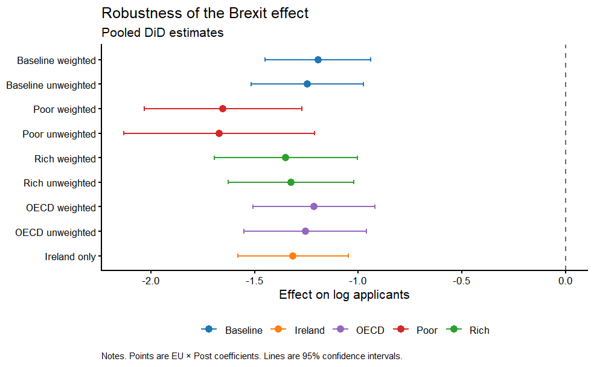

```r
models <- list(
  "Baseline weighted"   = models_baseline$weighted,
  "Baseline unweighted" = models_baseline$unweighted,
  "Poor weighted"       = models_poor$weighted,
  "Poor unweighted"     = models_poor$unweighted,
  "Rich weighted"       = models_rich$weighted,
  "Rich unweighted"     = models_rich$unweighted,
  "OECD weighted"       = models_oecd$weighted,
  "OECD unweighted"     = models_oecd$unweighted,
  "Ireland only"        = m_ireland_only
)

plot_data <- bind_rows(
  lapply(names(models), function(x) {
    tidy(models[[x]], conf.int = TRUE) %>%
      filter(term == "EU:Post") %>%
      mutate(model = x)
  })
) %>%
  mutate(
    model = factor(model, levels = rev(names(models))),
    group = case_when(
      grepl("Baseline", model) ~ "Baseline",
      grepl("Poor", model) ~ "Poor",
      grepl("Rich", model) ~ "Rich",
      grepl("OECD", model) ~ "OECD",
      grepl("Ireland", model) ~ "Ireland",
      TRUE ~ "Other"
    )
  )

ggplot(plot_data, aes(x = estimate, y = model, colour = group)) +
  geom_vline(xintercept = 0, linetype = "dashed", colour = "grey40") +
  geom_errorbarh(aes(xmin = conf.low, xmax = conf.high), height = 0.18) +
  geom_point(size = 2.7) +
  scale_colour_manual(
    values = c(
      "Baseline" = "#1F77B4",
      "Poor" = "#D62728",
      "Rich" = "#2CA02C",
      "OECD" = "#9467BD",
      "Ireland" = "#FF7F0E"
    )
  ) +
  labs(
    title = "Robustness of the Brexit effect",
    subtitle = "Pooled DiD estimates",
    x = "Effect on log applicants",
    y = NULL,
    colour = NULL,
    caption = "Notes. Points are EU × Post coefficients. Lines are 95% confidence intervals."
  ) +
  theme_classic(base_size = 11) +
  theme(
    legend.position = "bottom",
    axis.text = element_text(size = 9),
    plot.caption = element_text(size = 8, hjust = 0)
  )
```

# Robustness P.II

## Step 1. Prepare the data

```r
prepare_saturated_data <- function(df) {

  df %>%
    mutate(
      treated_factor = case_when(
        Domicile_named_country %in% eu_real ~ Domicile_named_country,
        TRUE ~ "CONTROL"
      ),
      treated_factor = factor(treated_factor)
    )
}
```

Next, we run all the datasets that need some changes:

```r
data_baseline_sat <- prepare_saturated_data(data_baseline_w)
data_poor_sat     <- prepare_saturated_data(data_poor_w)
data_rich_sat     <- prepare_saturated_data(data_rich_w)
data_oecd_sat     <- prepare_saturated_data(data_oecd_w)
```

## Step 2. Run the saturated designs

```r
run_saturated_models <- function(df) {

  m_weighted <- feols(
    log_applicants ~ i(treated_factor, Post, ref = "CONTROL") | Domicile_named_country + Year,
    data = df,
    weights = ~ robustness_weight,
    panel.id = ~ Domicile_named_country + Year,
    vcov = "DK"
  )

  m_unweighted <- feols(
    log_applicants ~ i(treated_factor, Post, ref = "CONTROL")| Domicile_named_country + Year,
    data = df,
    panel.id = ~ Domicile_named_country + Year,
    vcov = "DK"
  )

  list(
    weighted = m_weighted,
    unweighted = m_unweighted
  )
}
```

```r
etable(sat_baseline, sat_poor, sat_rich, sat_oecd)
```

```
                                                         weighted          unweighted
Dependent Var.:                                    log_applicants      log_applicants

Post x treated_factor = Austria               -0.6347*** (0.0741) -0.6860*** (0.0806)
Post x treated_factor = Belgium               -0.6888*** (0.0874) -0.7402*** (0.0944)
Post x treated_factor = Bulgaria               -1.973*** (0.1529)  -2.025*** (0.1598)
Post x treated_factor = Croatia                -1.741*** (0.1223)  -1.792*** (0.1312)
Post x treated_factor = Cyprus(EuropeanUnion) -0.9883*** (0.0932)  -1.040*** (0.0972)
Post x treated_factor = CzechRepublic          -1.223*** (0.0585)  -1.275*** (0.0654)
Post x treated_factor = Denmark                -1.133*** (0.1251)  -1.184*** (0.1337)
Post x treated_factor = Estonia                -1.534*** (0.1383)  -1.585*** (0.1451)
Post x treated_factor = Finland                -1.842*** (0.2272)  -1.894*** (0.2348)
Post x treated_factor = France                -0.6832*** (0.0783) -0.7346*** (0.0860)
Post x treated_factor = Germany               -0.7676*** (0.0946) -0.8190*** (0.1011)
Post x treated_factor = Greece                -0.9519*** (0.0974)  -1.003*** (0.1040)
Post x treated_factor = Hungary                -1.201*** (0.0824)  -1.252*** (0.0902)
Post x treated_factor = Italy                  -1.011*** (0.1333)  -1.063*** (0.1401)
Post x treated_factor = Latvia                 -1.598*** (0.1385)  -1.649*** (0.1470)
Post x treated_factor = Lithuania              -2.259*** (0.2912)  -2.311*** (0.3004)
Post x treated_factor = Luxembourg            -0.5790*** (0.0611) -0.6304*** (0.0684)
Post x treated_factor = Malta                 -0.4478*** (0.0453) -0.4992*** (0.0492)
Post x treated_factor = Netherlands           -0.6211*** (0.0423) -0.6725*** (0.0474)
Post x treated_factor = Poland                 -1.754*** (0.1570)  -1.806*** (0.1658)
Post x treated_factor = Portugal                 -1.025* (0.3564)    -1.077* (0.3659)
Post x treated_factor = Romania                -1.798*** (0.1509)  -1.849*** (0.1586)
Post x treated_factor = Slovakia               -1.602*** (0.1207)  -1.654*** (0.1262)
Post x treated_factor = Slovenia               -1.366*** (0.1419)  -1.417*** (0.1490)
Post x treated_factor = Spain                 -0.5938*** (0.0782) -0.6452*** (0.0866)
Post x treated_factor = Sweden                 -1.053*** (0.1604)  -1.104*** (0.1674)
Fixed-Effects:                                ------------------- -------------------
Domicile_named_country                                        Yes                 Yes
Year                                                          Yes                 Yes
________________________________________      ___________________ ___________________
S.E. type                                     Driscoll-Kra. (L=1) Driscoll-Kra. (L=1)
Observations                                                  520                 520
R2                                                        0.96768             0.98061
Within R2                                                 0.76934             0.80986

                                                       weighted.1        unweighted.1
Dependent Var.:                                    log_applicants      log_applicants
```

[output cut: 98 more lines]

```
Post x treated_factor = Romania                -1.817*** (0.1693)  -1.858*** (0.1694)
Post x treated_factor = Slovakia               -1.622*** (0.1341)  -1.663*** (0.1304)
Post x treated_factor = Slovenia               -1.385*** (0.1608)  -1.427*** (0.1631)
Post x treated_factor = Spain                 -0.6134*** (0.0893) -0.6547*** (0.0902)
Post x treated_factor = Sweden                 -1.073*** (0.1824)  -1.114*** (0.1812)
Fixed-Effects:                                ------------------- -------------------
Domicile_named_country                                        Yes                 Yes
Year                                                          Yes                 Yes
________________________________________      ___________________ ___________________
S.E. type                                     Driscoll-Kra. (L=1) Driscoll-Kra. (L=1)
Observations                                                  400                 400
R2                                                        0.97147             0.98225
Within R2                                                 0.77643             0.81597
---
Signif. codes: 0 '***' 0.001 '**' 0.01 '*' 0.05 '.' 0.1 ' ' 1
```

Next we run a saturated DID with Ireland being the only counterfactual. The primary reason why we do not weight this specification is because the weight will not affect the coefficients.

```r
data_ireland <- data_clean %>%
  filter(Domicile_named_country %in% c(eu_real, "Ireland"))

data_ireland_sat <- data_ireland %>%
  mutate(
    treated_factor = ifelse(
      Domicile_named_country %in% eu_real, #because eu_real does not contain ireland either way
      Domicile_named_country,
      "IRELAND"
    ),
    treated_factor = factor(treated_factor),
    regression_weight=ifelse(Domicile_named_country %in% "Ireland", 26, 1)
  )

sat_ireland_only <- feols(
  log_applicants ~ i(treated_factor,Post, ref="IRELAND") | Domicile_named_country + Year,
  data = data_ireland_sat,
  panel.id = ~ Domicile_named_country + Year,
  vcov = "DK"
)
```

```r
etable(
  sat_baseline$weighted,
  sat_baseline$unweighted,
  sat_poor$weighted,
  sat_poor$unweighted,
  sat_rich$weighted,
  sat_rich$unweighted,
  sat_oecd$weighted,
  sat_oecd$unweighted,
  sat_ireland_only,
  headers = c(
    "Baseline weighted",
    "Baseline unweighted",
    "Poor weighted",
    "Poor unweighted",
    "Rich weighted",
    "Rich unweighted",
    "OECD weighted",
    "OECD unweighted",
    "Ireland only"
  ),
  fitstat = ~ n + ar2 + wr2,
  tex = FALSE
)
```

```
                                              sat_baseline$weig.. sat_baseline$unwe..
                                                Baseline weighted Baseline unweighted
Dependent Var.:                                    log_applicants      log_applicants

Post x treated_factor = Austria               -0.6347*** (0.0741) -0.6860*** (0.0806)
Post x treated_factor = Belgium               -0.6888*** (0.0874) -0.7402*** (0.0944)
Post x treated_factor = Bulgaria               -1.973*** (0.1529)  -2.025*** (0.1598)
Post x treated_factor = Croatia                -1.741*** (0.1223)  -1.792*** (0.1312)
Post x treated_factor = Cyprus(EuropeanUnion) -0.9883*** (0.0932)  -1.040*** (0.0972)
Post x treated_factor = CzechRepublic          -1.223*** (0.0585)  -1.275*** (0.0654)
Post x treated_factor = Denmark                -1.133*** (0.1251)  -1.184*** (0.1337)
Post x treated_factor = Estonia                -1.534*** (0.1383)  -1.585*** (0.1451)
Post x treated_factor = Finland                -1.842*** (0.2272)  -1.894*** (0.2348)
Post x treated_factor = France                -0.6832*** (0.0783) -0.7346*** (0.0860)
Post x treated_factor = Germany               -0.7676*** (0.0946) -0.8190*** (0.1011)
Post x treated_factor = Greece                -0.9519*** (0.0974)  -1.003*** (0.1040)
Post x treated_factor = Hungary                -1.201*** (0.0824)  -1.252*** (0.0902)
Post x treated_factor = Italy                  -1.011*** (0.1333)  -1.063*** (0.1401)
Post x treated_factor = Latvia                 -1.598*** (0.1385)  -1.649*** (0.1470)
Post x treated_factor = Lithuania              -2.259*** (0.2912)  -2.311*** (0.3004)
Post x treated_factor = Luxembourg            -0.5790*** (0.0611) -0.6304*** (0.0684)
Post x treated_factor = Malta                 -0.4478*** (0.0453) -0.4992*** (0.0492)
Post x treated_factor = Netherlands           -0.6211*** (0.0423) -0.6725*** (0.0474)
Post x treated_factor = Poland                 -1.754*** (0.1570)  -1.806*** (0.1658)
Post x treated_factor = Portugal                 -1.025* (0.3564)    -1.077* (0.3659)
Post x treated_factor = Romania                -1.798*** (0.1509)  -1.849*** (0.1586)
Post x treated_factor = Slovakia               -1.602*** (0.1207)  -1.654*** (0.1262)
Post x treated_factor = Slovenia               -1.366*** (0.1419)  -1.417*** (0.1490)
Post x treated_factor = Spain                 -0.5938*** (0.0782) -0.6452*** (0.0866)
Post x treated_factor = Sweden                 -1.053*** (0.1604)  -1.104*** (0.1674)
Fixed-Effects:                                ------------------- -------------------
Domicile_named_country                                        Yes                 Yes
Year                                                          Yes                 Yes
________________________________________      ___________________ ___________________
S.E. type                                     Driscoll-Kra. (L=1) Driscoll-Kra. (L=1)
Observations                                                  520                 520
Adj. R2                                                   0.96126             0.97676
Within R2                                                 0.76934             0.80986

                                                sat_poor$weighted sat_poor$unweighted
```

[output cut: 141 more lines]

```
Post x treated_factor = Romania                -1.917*** (0.1585)
Post x treated_factor = Slovakia               -1.722*** (0.1589)
Post x treated_factor = Slovenia               -1.485*** (0.1418)
Post x treated_factor = Spain                 -0.7136*** (0.1238)
Post x treated_factor = Sweden                 -1.173*** (0.1572)
Fixed-Effects:                                -------------------
Domicile_named_country                                        Yes
Year                                                          Yes
________________________________________      ___________________
S.E. type                                     Driscoll-Kra. (L=1)
Observations                                                  270
Adj. R2                                                   0.98735
Within R2                                                 0.83346
---
Signif. codes: 0 '***' 0.001 '**' 0.01 '*' 0.05 '.' 0.1 ' ' 1
```

## Step 3. Simple line plot comparing models

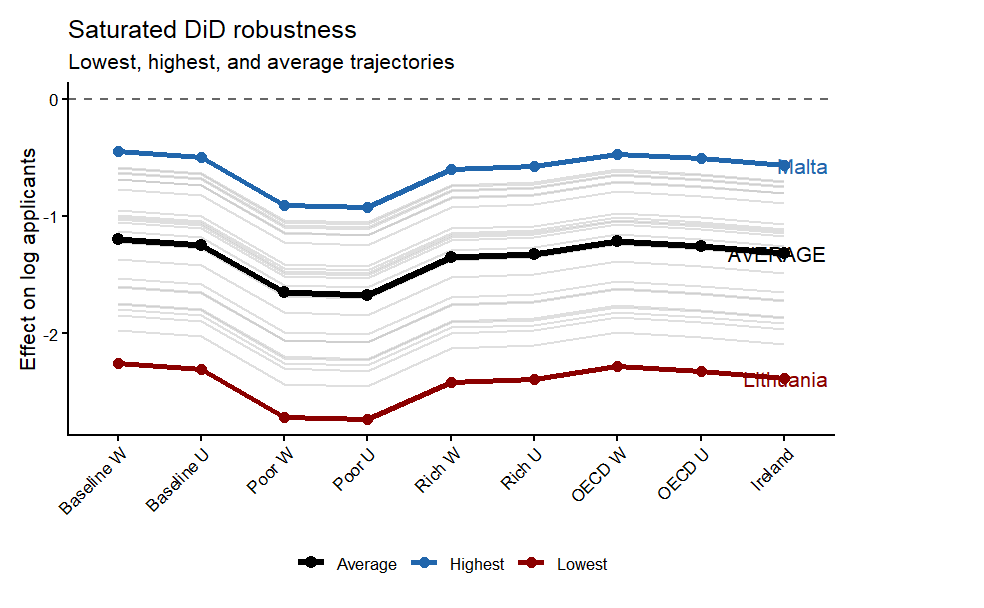

```r
library(dplyr)
library(broom)
library(stringr)
library(ggplot2)
library(ggrepel)

models <- list(
  "Baseline W" = sat_baseline$weighted,
  "Baseline U" = sat_baseline$unweighted,
  "Poor W" = sat_poor$weighted,
  "Poor U" = sat_poor$unweighted,
  "Rich W" = sat_rich$weighted,
  "Rich U" = sat_rich$unweighted,
  "OECD W" = sat_oecd$weighted,
  "OECD U" = sat_oecd$unweighted,
  "Ireland" = sat_ireland_only
)

sat <- bind_rows(lapply(names(models), function(m) {
  tidy(models[[m]], conf.int = TRUE) %>%
    filter(str_detect(term, "treated_factor::.*:Post")) %>%
    mutate(
      model = m,
      country = str_replace_all(term, "treated_factor::|:Post", "")
    )
}))

sat$model <- factor(sat$model, levels = names(models))

ranked <- sat %>%
  group_by(country) %>%
  summarise(avg = mean(estimate), .groups = "drop") %>%
  arrange(avg)

low <- ranked$country[1]
high <- ranked$country[nrow(ranked)]

sat <- sat %>%
  mutate(group = case_when(
    country == low ~ "Lowest",
    country == high ~ "Highest",
    TRUE ~ "Other"
  ))

avg <- sat %>%
  group_by(model) %>%
  summarise(estimate = mean(estimate), .groups = "drop") %>%
  mutate(country = "AVERAGE", group = "Average")

labels <- bind_rows(
  sat %>% filter(country %in% c(low, high), model == "Ireland"),
  avg %>% filter(model == "Ireland")
)

ggplot() +
  geom_hline(yintercept = 0, linetype = "dashed", colour = "grey40") +
  geom_line(
    data = sat %>% filter(group == "Other"),
    aes(model, estimate, group = country),
    colour = "grey75",
    alpha = 0.5
  ) +
  geom_line(
    data = sat %>% filter(group != "Other"),
    aes(model, estimate, group = country, colour = group),
    linewidth = 1.3
  ) +
  geom_line(
    data = avg,
    aes(model, estimate, group = country, colour = group),
    linewidth = 1.5
  ) +
  geom_point(
    data = sat %>% filter(group != "Other"),
    aes(model, estimate, colour = group),
    size = 2.4
  ) +
  geom_point(
    data = avg,
    aes(model, estimate, colour = group),
    size = 2.6
  ) +
  geom_text_repel(
    data = labels,
    aes(model, estimate, label = country, colour = group),
    nudge_x = 0.4,
    hjust = 0,
    show.legend = FALSE
  ) +
  scale_colour_manual(values = c(
    "Lowest" = "#8B0000",
    "Highest" = "#2166AC",
    "Average" = "black"
  )) +
  coord_cartesian(clip = "off") +
  labs(
    title = "Saturated DiD robustness",
    subtitle = "Lowest, highest, and average trajectories",
    x = NULL,
    y = "Effect on log applicants",
    colour = NULL
  ) +
  theme_classic(base_size = 11) +
  theme(
    axis.text.x = element_text(angle = 45, hjust = 1),
    legend.position = "bottom",
    plot.margin = margin(10, 80, 10, 10)
  )
```

# Controls for wealth heterogeneity

First we are going to make a copy of the main database with a specific DID indicator to estimate the AVERAGE treatment effects.

```r
# Make a copy of the baseline panel df.

data_panel_WB <- df %>%
  mutate(
    log_app = log(Applicants),
    EU = as.numeric(Domicile_named_country %in% eu_real),
    Post = as.numeric(Year >= 2021),
    did = EU * Post
  ) %>%
  filter(!is.na(log_app))
```

Now we need to make a targeted pull into the WB API resources and extract information about:

```r
library(WDI)
library(countrycode)
library(dplyr)

panel_countries <- unique(data_panel_WB$Domicile_named_country)

iso_map <- data.frame(Domicile_named_country = panel_countries) %>%
  mutate(
    iso2c = countrycode(
      Domicile_named_country, "country.name", "iso2c",
      custom_match = c("Cyprus (European Union)" = "CY"),
      warn = TRUE
    ),
    iso3c = countrycode(iso2c, "iso2c", "iso3c", warn = FALSE)
  )

# safety net, this should print zero rows
iso_map[is.na(iso_map$iso2c), ]
```

| Domicile_named_country | iso2c | iso3c |
| --- | --- | --- |

```r
wb_codes <- c(
  GDPpc       = "NY.GDP.PCAP.KD",    # GDP per capita, constant 2015 US$
  Pop15_65    = "SP.POP.1564.TO",    # population ages 15-64, total (band is 15-64)
  YouthUnempl = "SL.UEM.1524.ZS",    # unemployment, ages 15-24, modeled ILO
  EduSpendGDP = "SE.XPD.TOTL.GD.ZS"  # govt expenditure on education, % of GDP
)

yr_min <- min(data_panel_WB$Year, na.rm = TRUE)
yr_max <- max(data_panel_WB$Year, na.rm = TRUE)

wb_raw <- WDI(
  country   = na.omit(iso_map$iso2c),
  indicator = wb_codes,
  start     = yr_min,
  end       = yr_max
)

wb_clean <- wb_raw %>%
  transmute(iso3c, Year = as.integer(year),
            GDPpc, Pop15_65, YouthUnempl, EduSpendGDP)
```

```r
data_panel_WB <- data_panel_WB %>%
  mutate(Year = as.integer(Year)) %>%
  left_join(iso_map[, c("Domicile_named_country", "iso3c")],
            by = "Domicile_named_country") %>%
  left_join(wb_clean, by = c("iso3c", "Year"))
```

[output not shown]

```r
#Quick inspection of the data in excel
library(openxlsx)
write.xlsx(data_panel_WB, "data_panel_WB.xlsx")
```

Now some of the regressions:

```r
library(fixest)
library(dplyr)
library(modelsummary)

data_panel_WB <- data_panel_WB %>%
  mutate(
    c_log_GDPpc    = log(GDPpc)    - mean(log(GDPpc), na.rm = TRUE),
    c_log_Pop15_65 = log(Pop15_65) - mean(log(Pop15_65), na.rm = TRUE),
    c_YouthUnempl  = YouthUnempl   - mean(YouthUnempl, na.rm = TRUE)
  )

# M1 — Clean baseline DiD
m1 <- feols(
  log_app ~ did | Domicile_named_country + Year,
  data = data_panel_WB ,
  panel.id = ~Domicile_named_country + Year,
  vcov = "DK",
  weights = ~regression_weight
)

# M2 — Add GDP
m2 <- feols(
  log_app ~ did + c_log_GDPpc  | Domicile_named_country + Year,
  data = data_panel_WB ,
  panel.id = ~Domicile_named_country + Year,
  vcov = "DK",
  weights = ~regression_weight
)

# M4 — Add Pop15_65
m4 <- feols(
  log_app ~ did +c_log_GDPpc  +c_log_Pop15_65 | Domicile_named_country + Year,
  data = data_panel_WB ,
  panel.id = ~Domicile_named_country + Year,
  vcov = "DK",
  weights = ~regression_weight
)

# M5 — Add YouthUnempl + Pop15_65
m5 <- feols(
  log_app ~ did + c_log_GDPpc  + c_YouthUnempl + c_log_Pop15_65 | Domicile_named_country + Year,
  data = data_panel_WB ,
  panel.id = ~Domicile_named_country + Year,
  vcov = "DK",
  weights = ~regression_weight
)

# M6 — Fully interacted structural channels
m6 <- feols(
  log_app ~ did * (c_log_GDPpc  + c_log_Pop15_65 + c_YouthUnempl) | Domicile_named_country + Year,
  data = data_panel_WB ,
  panel.id = ~Domicile_named_country + Year,
  vcov = "DK",
  weights = ~regression_weight
)

modelsummary(
  list(
    "M1" = m1,
    "M2" = m2,
    "M4" = m4,
    "M5" = m5,
    "M6" = m6
  ),
  stars = TRUE,
  output = "default"
)
```

|  | M1 | M2 | M4 | M5 | M6 |
| --- | --- | --- | --- | --- | --- |
| did | -1.075*** | -1.049*** | -0.981*** | -0.961*** | -1.156*** |
|  | (0.112) | (0.111) | (0.101) | (0.092) | (0.106) |
| c_log_GDPpc |  | -0.730* | -0.442 | -0.685* | 0.261 |
|  |  | (0.270) | (0.262) | (0.286) | (0.300) |
| c_log_Pop15_65 |  |  | 3.076*** | 3.212*** | 2.452*** |
|  |  |  | (0.458) | (0.519) | (0.434) |
| c_YouthUnempl |  |  |  | -0.014* | -0.005 |
|  |  |  |  | (0.004) | (0.003) |
| did × c_log_GDPpc |  |  |  |  | 0.489*** |
|  |  |  |  |  | (0.074) |
| did × c_log_Pop15_65 |  |  |  |  | 0.088*** |
|  |  |  |  |  | (0.015) |
| did × c_YouthUnempl |  |  |  |  | 0.008 |
|  |  |  |  |  | (0.006) |
| Num.Obs. | 467 | 467 | 467 | 467 | 467 |
| R2 | 0.963 | 0.963 | 0.968 | 0.969 | 0.975 |
| R2 Adj. | 0.957 | 0.958 | 0.964 | 0.964 | 0.971 |
| R2 Within | 0.578 | 0.586 | 0.643 | 0.652 | 0.722 |
| R2 Within Adj. | 0.577 | 0.584 | 0.641 | 0.648 | 0.717 |
| AIC | 122.4 | 125.2 | 54.9 | 58.8 | -40.9 |
| BIC | 375.3 | 382.3 | 316.1 | 324.1 | 236.9 |
| RMSE | 0.24 | 0.24 | 0.22 | 0.22 | 0.20 |
| Std.Errors | Driscoll-Kraay (L=1) | Driscoll-Kraay (L=1) | Driscoll-Kraay (L=1) | Driscoll-Kraay (L=1) | Driscoll-Kraay (L=1) |
| FE: Domicile_named_country | X | X | X | X | X |
| FE: Year | X | X | X | X | X |

+ p < 0.1, * p < 0.05, ** p < 0.01, *** p < 0.001

```r
wald(m6, c("did:c_log_GDPpc", "did:c_log_Pop15_65", "did:c_YouthUnempl"))
```

```
Wald test, H0: joint nullity of did:c_log_GDPpc, did:c_log_Pop15_65 and did:c_YouthUnempl
 stat = 142.7, p-value < 2.2e-16, on 3 and 400 DoF, VCOV: Driscoll-Kraay (L=1).
```

The two-way fixed effects estimates indicate a large and robust contraction in EU applications following the 2021 fee reform. The baseline specification places the effect at -1.075, and the point estimate remains essentially unchanged as macroeconomic and demographic controls are added in sequence, settling at -0.961 in the fully controlled additive model (M5). Translated into levels, this corresponds to a fall in EU applicant volumes of approximately 62%. The persistence of the coefficient across specifications indicates that the result is not an artifact of cross-country differences in income, working-age population, or youth labour market conditions.

The fully interacted specification (M6) allows the treatment effect to vary with these structural characteristics. A Wald test rejects joint nullity of the interaction terms, F(3, 400) = 142.7, p < 0.001, confirming that the response to the fee shock was significantly heterogeneous. The interactions with GDP per capita (0.489, p < 0.001) and working-age population (0.088, p < 0.001) are both positive, indicating that the contraction was attenuated among wealthier and demographically larger origin countries. Applicants from higher-income states with larger youth cohorts were better able to absorb the increase in tuition and the loss of home-fee status, while the interaction with youth unemployment is statistically indistinguishable from zero.

```r
# Here we will recycle the "data_panel" data set that we used in the previous chunk because we know that it is reliable abd already contains the macroeconomic fundamentals

df_sat_WB <- data_panel_WB %>%
  mutate(
    Domicile_named_country = as.character(Domicile_named_country),
    Year = as.integer(Year),

    # treatment
    Post = as.integer(Year >= 2021),
    Treated = as.integer(Domicile_named_country %in% eu_real),

    # pooled control group for saturated DiD
    treated_factor = ifelse(
      Treated == 1,
      Domicile_named_country,
      "CONTROL"
    )) %>%
  filter(
    !is.na(log_app),
    !is.na(Post),
    !is.na(treated_factor)
  )
```

```r
# S1: saturated DiD only
s1 <- feols(
  log_app ~ i(treated_factor, Post, ref = "CONTROL") |
    Domicile_named_country + Year,
  data = df_sat_WB,
  panel.id = ~ Domicile_named_country + Year,
  vcov = "DK",
  weights = ~regression_weight
)

# S2: add GDP
s2 <- feols(
  log_app ~ i(treated_factor, Post, ref = "CONTROL") +  c_log_GDPpc |
    Domicile_named_country + Year,
  panel.id = ~ Domicile_named_country + Year,  data = df_sat_WB,
  vcov = "DK",
  weights = ~regression_weight
)

# S3: add GDP + working-age population
s3 <- feols(
  log_app ~ i(treated_factor, Post, ref = "CONTROL") +
    c_log_GDPpc + c_log_Pop15_65 |
    Domicile_named_country + Year,
  data = df_sat_WB,
  panel.id = ~ Domicile_named_country + Year,
  vcov = "DK",
  weights = ~regression_weight
)

# S4: add GDP + working-age population + youth unemployment
s4 <- feols(
  log_app ~ i(treated_factor, Post, ref = "CONTROL") +
    c_log_GDPpc + c_log_Pop15_65 + c_YouthUnempl  |
    Domicile_named_country + Year,
  panel.id = ~ Domicile_named_country + Year,
    data = df_sat_WB,
  vcov = "DK"
)
modelsummary(
  list(
    "S1 Saturated DiD" = s1,
    "S2 + GDPpc" = s2,
    "S3 + GDPpc + Pop" = s3,
    "S4 + GDPpc + Pop + YouthUnempl" = s4
  ),
  stars = TRUE,
  output = "default"
)
```

|  | S1 Saturated DiD | S2 + GDPpc | S3 + GDPpc + Pop | S4 + GDPpc + Pop + YouthUnempl |
| --- | --- | --- | --- | --- |
| treated_factor = Austria × Post | -0.529*** | -0.520*** | -0.497*** | -0.612*** |
|  | (0.059) | (0.059) | (0.052) | (0.070) |
| treated_factor = Belgium × Post | -0.581*** | -0.582*** | -0.570*** | -0.681*** |
|  | (0.074) | (0.071) | (0.064) | (0.081) |
| treated_factor = Bulgaria × Post | -1.855*** | -1.891*** | -1.774*** | -1.926*** |
|  | (0.151) | (0.140) | (0.097) | (0.158) |
| treated_factor = Croatia × Post | -1.616*** | -1.661*** | -1.533*** | -1.660*** |
|  | (0.128) | (0.119) | (0.099) | (0.141) |
| treated_factor = Cyprus (European Union) × Post | -0.887*** | -0.923*** | -0.951*** | -1.028*** |
|  | (0.070) | (0.061) | (0.063) | (0.091) |
| treated_factor = Czech Republic × Post | -1.121*** | -1.120*** | -1.069*** | -1.191*** |
|  | (0.065) | (0.060) | (0.071) | (0.067) |
| treated_factor = Denmark × Post | -1.034*** | -1.037*** | -1.025*** | -1.134*** |
|  | (0.133) | (0.128) | (0.123) | (0.142) |
| treated_factor = Estonia × Post | -1.412*** | -1.412*** | -1.392*** | -1.531*** |
|  | (0.133) | (0.124) | (0.120) | (0.146) |
| treated_factor = Finland × Post | -1.680*** | -1.668*** | -1.623*** | -1.719*** |
|  | (0.220) | (0.221) | (0.206) | (0.217) |
| treated_factor = France × Post | -0.575*** | -0.570*** | -0.540*** | -0.629*** |
|  | (0.069) | (0.069) | (0.058) | (0.068) |
| treated_factor = Germany × Post | -0.659*** | -0.649*** | -0.578*** | -0.696*** |
|  | (0.078) | (0.079) | (0.053) | (0.077) |
| treated_factor = Greece × Post | -0.819*** | -0.837*** | -0.737*** | -0.805*** |
|  | (0.067) | (0.061) | (0.036) | (0.060) |
| treated_factor = Hungary × Post | -1.076*** | -1.100*** | -1.010*** | -1.161*** |
|  | (0.086) | (0.083) | (0.080) | (0.084) |
| treated_factor = Italy × Post | -0.886*** | -0.893*** | -0.823*** | -0.894*** |
|  | (0.120) | (0.114) | (0.092) | (0.105) |
| treated_factor = Latvia × Post | -1.474*** | -1.489*** | -1.383*** | -1.520*** |
|  | (0.155) | (0.147) | (0.127) | (0.146) |
| treated_factor = Lithuania × Post | -2.163*** | -2.189*** | -2.159*** | -2.281*** |
|  | (0.351) | (0.338) | (0.335) | (0.376) |
| treated_factor = Luxembourg × Post | -0.505*** | -0.488*** | -0.573*** | -0.653*** |
|  | (0.056) | (0.056) | (0.085) | (0.085) |
| treated_factor = Malta × Post | -0.351*** | -0.379*** | -0.527*** | -0.599*** |
|  | (0.045) | (0.051) | (0.068) | (0.093) |
| treated_factor = Netherlands × Post | -0.520*** | -0.523*** | -0.522*** | -0.630*** |
|  | (0.024) | (0.023) | (0.024) | (0.038) |
| treated_factor = Poland × Post | -1.612*** | -1.653*** | -1.520*** | -1.669*** |
|  | (0.167) | (0.155) | (0.133) | (0.166) |
| treated_factor = Portugal × Post | -0.863+ | -0.867+ | -0.833+ | -0.942+ |
|  | (0.425) | (0.425) | (0.422) | (0.432) |
| treated_factor = Romania × Post | -1.653*** | -1.682*** | -1.580*** | -1.755*** |
|  | (0.155) | (0.147) | (0.126) | (0.166) |
| treated_factor = Slovakia × Post | -1.472*** | -1.483*** | -1.385*** | -1.534*** |
|  | (0.118) | (0.114) | (0.117) | (0.097) |
| treated_factor = Slovenia × Post | -1.201*** | -1.219*** | -1.172*** | -1.296*** |
|  | (0.122) | (0.118) | (0.100) | (0.138) |
| treated_factor = Spain × Post | -0.492*** | -0.487** | -0.489** | -0.541** |
|  | (0.095) | (0.098) | (0.100) | (0.112) |
| treated_factor = Sweden × Post | -0.910*** | -0.905*** | -0.915*** | -1.039*** |
|  | (0.144) | (0.143) | (0.141) | (0.160) |
| c_log_GDPpc |  | 0.312 | 0.374 | 0.502* |
|  |  | (0.257) | (0.261) | (0.192) |
| c_log_Pop15_65 |  |  | 1.656** | 1.206* |
|  |  |  | (0.365) | (0.456) |
| c_YouthUnempl |  |  |  | 0.007 |
|  |  |  |  | (0.004) |
| Num.Obs. | 467 | 467 | 467 | 467 |
| R2 | 0.984 | 0.984 | 0.985 | 0.983 |
| R2 Adj. | 0.980 | 0.980 | 0.982 | 0.980 |
| R2 Within | 0.817 | 0.818 | 0.830 | 0.827 |
| R2 Within Adj. | 0.804 | 0.805 | 0.818 | 0.814 |
| AIC | -154.2 | -158.8 | -194.2 | -217.5 |
| BIC | 202.4 | 201.9 | 170.7 | 151.5 |
| RMSE | 0.17 | 0.17 | 0.16 | 0.16 |
| Std.Errors | Driscoll-Kraay (L=1) | Driscoll-Kraay (L=1) | Driscoll-Kraay (L=1) | Driscoll-Kraay (L=1) |
| FE: Domicile_named_country | X | X | X | X |
| FE: Year | X | X | X | X |

+ p < 0.1, * p < 0.05, ** p < 0.01, *** p < 0.001

## Plot saturated effects

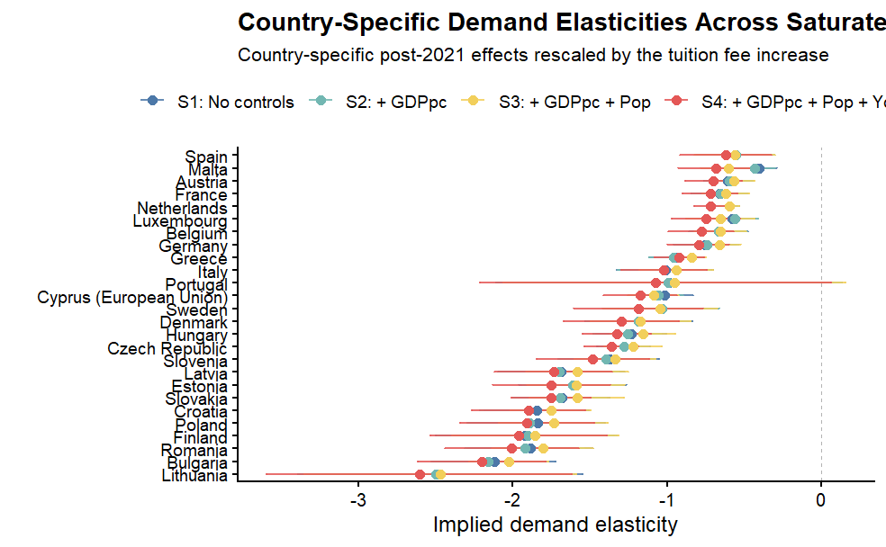

```r
library(dplyr)
library(ggplot2)
library(tidyr)
library(broom)
library(stringr)
library(purrr)

fee_pre  <- 9250
fee_post <- 22200
log_fee_change <- log(fee_post) - log(fee_pre)  # log fee change, about 0.875

# models
mods <- list(
  "S1: No controls" = s1,
  "S2: + GDPpc" = s2,
  "S3: + GDPpc + Pop" = s3,
  "S4: + GDPpc + Pop + YouthUnempl" = s4
)

# extract country-specific coefficients and convert to elasticity
coef_long <- imap_dfr(mods, function(mod, mod_name) {
  tidy(mod, conf.int = TRUE) %>%
    mutate(
      model = mod_name,
      term = as.character(term)
    ) %>%
    filter(str_detect(term, "treated_factor")) %>%
    mutate(
      country = term %>%
        str_remove(".*treated_factor::") %>%
        str_remove("[#:]Post.*")
    ) %>%
    filter(country != "CONTROL") %>%
    mutate(
      elasticity = estimate  / log_fee_change,
      elas_low   = conf.low  / log_fee_change,
      elas_high  = conf.high / log_fee_change
    )
})

# order countries by S4 elasticity
country_order <- coef_long %>%
  filter(model == "S4: + GDPpc + Pop + YouthUnempl") %>%
  arrange(elasticity) %>%
  pull(country)

plot_df <- coef_long %>%
  mutate(
    country = factor(country, levels = country_order),
    model = factor(
      model,
      levels = c(
        "S1: No controls",
        "S2: + GDPpc",
        "S3: + GDPpc + Pop",
        "S4: + GDPpc + Pop + YouthUnempl"
      )
    )
  )

ggplot(plot_df, aes(x = elasticity, y = country, color = model, group = country)) +
  geom_line(color = "grey75", linewidth = 0.5) +
  geom_errorbarh(
    aes(xmin = elas_low, xmax = elas_high),
    height = 0.12,
    linewidth = 0.5,
    alpha = 0.85
  ) +
  geom_point(size = 2.4) +
  geom_vline(
    xintercept = 0,
    linetype = "dashed",
    color = "grey70",
    linewidth = 0.35
  ) +
  scale_color_manual(
    values = c(
      "S1: No controls" = "#4C78A8",
      "S2: + GDPpc" = "#72B7B2",
      "S3: + GDPpc + Pop" = "#F2CF5B",
      "S4: + GDPpc + Pop + YouthUnempl" = "#E45756"
    ),
    name = NULL
  ) +
  labs(
    title = "Country-Specific Demand Elasticities Across Saturated DiD Specifications",
    subtitle = "Country-specific post-2021 effects rescaled by the tuition fee increase",
    x = "Implied demand elasticity",
    y = ""
  ) +
  theme_classic(base_size = 13) +
  theme(
    plot.title = element_text(face = "bold", size = 15),
    plot.subtitle = element_text(size = 11),
    axis.text.y = element_text(size = 10),
    legend.position = "top",
    legend.text = element_text(size = 10)
  )
```